# R Notebook

Combine area and perc change area plots

```r
# Install patchwork if you haven't already
install.packages("patchwork")

# Load patchwork
library(patchwork)

# Combine the two plots side by side
combined_plot <- area_plot + perc_change_plot + plot_layout(ncol = 2)

# Display the combined plot
print(combined_plot)

# Save the combined plot as a PNG file
ggsave("combined_plot.png", plot = combined_plot, width = 12, height = 6, dpi = 300)
```

Percent change in size for survivors

```r
# Group by Treatment, Cross_2, and SymbiontTreatment, and calculate mean and standard error for percent change
perc_change_summary <- totaldf_long %>%
  filter(Timepoint == 22, Status == 0) %>%
  group_by(Treatment, Cross_2, SymbiontTreatment, ReefMom) %>%
  summarise(mean_perc_change = mean(PercChangeSize, na.rm = TRUE),
            se_perc_change = sd(PercChangeSize, na.rm = TRUE) / sqrt(n()))

all_combos <- expand.grid(
  Treatment = c("Ambient", "31"),
  Cross_2 = unique(totaldf_long$Cross_2),
  SymbiontTreatment = unique(totaldf_long$SymbiontTreatment),
  ReefMom = unique (totaldf_long$ReefMom),
  stringsAsFactors = FALSE
)

perc_change_summary <- all_combos %>%
  left_join(perc_change_summary, by = c("Treatment", "Cross_2", "SymbiontTreatment", "ReefMom")) %>%
  mutate(
    mean_area = ifelse(is.na(mean_perc_change), 0, mean_perc_change),
    se_area = ifelse(is.na(se_perc_change), 0, se_perc_change),
    Treatment = factor(Treatment, levels = c("Ambient", "31", "35.5"))  # Re-set factor levels
  )

# Define a custom color palette (same as before)
custom_colors <- c("CC" = "#1f77b4", "WW" = "#ff7f0e")  # Modify colors as needed

# Plot percent change in area with colors assigned to Cross_2 and separate panels for Family
survivors_perc_change <- ggplot(perc_change_summary, aes(x = Treatment, y = mean_perc_change,
                                                        fill = Cross_2, shape = SymbiontTreatment)) +
  geom_line(aes(group = interaction(Cross_2, SymbiontTreatment), color = Cross_2), size = 0.7) +  # connecting lines
  geom_point(size = 4, color = "black", stroke = 1.5) +  # points with black border
  geom_errorbar(aes(ymin = mean_perc_change - se_perc_change,
                    ymax = mean_perc_change + se_perc_change,
                    color = Cross_2), width = 0.2) +  # error bars matching fill color
  geom_hline(yintercept = 0, linetype = "dashed", color = "grey") +
  scale_fill_manual(values = custom_colors) +  # fill for points
  scale_color_manual(values = custom_colors) + # color for error bars and lines
  scale_shape_manual(values = c(21, 24)) + # shapes that support fill + border
  facet_wrap(~ ReefMom, nrow = 7) +
  labs(x = "Temperature (Treatment)", y = "Percent Change in Area (mm² ± s.e.)",
       title = "Percent Change in Larval Area (Survived to Timepoint 22)") +
  theme_minimal() +
  theme(
    legend.position = "right",
    panel.grid.major = element_blank(),
    panel.grid.minor = element_blank(),
    axis.line = element_line(color = "black", linewidth = 0.5),
    axis.ticks = element_line(color = "black")
  )


print(survivors_perc_change)

# Save the plot to a file
ggsave("percent_change_area_plot.png",
       plot = survivors_perc_change,  # Save the most recent plot
       width = 10,          # Set the width of the plot (in inches)
       height = 7,          # Set the height of the plot (in inches)
       dpi = 300)           # Set the resolution (300 dpi is good for publications)
```

Combine the 3 plots for size into one figure

```r
# Combine the three plots into one figure
combined_plot2 <- area_plot +  theme(legend.position = "none") +
  perc_change_plot +  theme(legend.position = "none") +
  survivors_perc_change +  theme(legend.position = "none") +
  plot_layout(ncol = 3)  # Stack them vertically (1 column)

# Display the combined plot
print(combined_plot2)

ggsave("C:/Users/bellb/OneDrive - James Cook University/Australia/Ningaloo Spawning 2024/combined_plot_size.png",
       plot = combined_plot2,  # Save the most recent plot
       width = 10,          # Set the width of the plot (in inches)
       height = 7,          # Set the height of the plot (in inches)
       dpi = 300)           # Set the resolution (300 dpi is good for publications)
```

Plot of mean FV/FM at T22 (first measurements taken at T4)

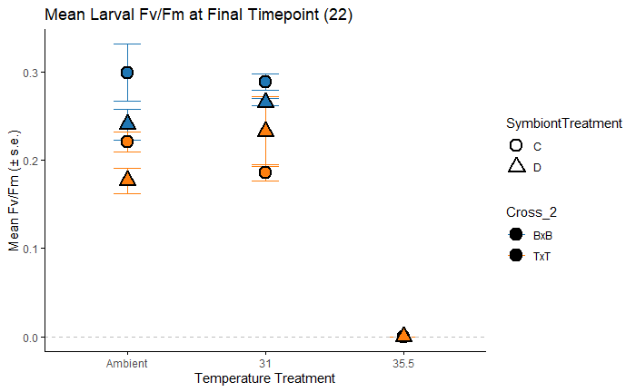

Plot of raw change in Fv/Fm (% change has too large of error margins for survivors GLMM)

| Treatment | mean_raw_change | se_raw_change |
| --- | --- | --- |
| Ambient | -0.01631385 | 0.00919167 |
| 31 | 0.06198754 | 0.01257632 |

Raw change in FVFM for survivors

```r
# Save the plot to a file
ggsave("C:/Users/jc980786/OneDrive - James Cook University/Australia/Ningaloo Spawning 2024/survivors_raw_change_plot.png",
       plot = survivors_raw_change,
       width = 10,
       height = 7,
       dpi = 300)
```

```r
ggsave("C:/Users/jc980786/OneDrive - James Cook University/Australia/Ningaloo Spawning 2024/combined_plot_fvfm_raw.png",
       plot = combined_plot3,
       width = 10,
       height = 7,
       dpi = 300)
```

Percentage of Larvae with Cells: line graphs

| Timepoint | SymbiontTreatment | Treatment | Cross | mean_pct | n | sd_pct | se | ci_lower | ci_upper |
| --- | --- | --- | --- | --- | --- | --- | --- | --- | --- |
| 22 | C | Ambient | CC | 30.00000 | 6 | 10.954451 | 4.472136 | 18.504009 | 41.49599 |
| 22 | C | Ambient | WW | 20.00000 | 11 | 0.000000 | 0.000000 | 20.000000 | 20.00000 |
| 22 | C | 31 | CC | 20.00000 | 3 | 0.000000 | 0.000000 | 20.000000 | 20.00000 |
| 22 | C | 31 | WW | 25.00000 | 4 | 10.000000 | 5.000000 | 9.087768 | 40.91223 |
| 22 | D | Ambient | CC | 25.71429 | 7 | 9.759001 | 3.688556 | 16.688715 | 34.73986 |
| 22 | D | Ambient | WW | 22.00000 | 10 | 6.324555 | 2.000000 | 17.475686 | 26.52431 |
| 22 | D | 31 | CC | 20.00000 | 4 | 0.000000 | 0.000000 | 20.000000 | 20.00000 |
| 22 | D | 31 | WW | 20.00000 | 4 | 0.000000 | 0.000000 | 20.000000 | 20.00000 |

PercentageWithCells from Day 1 to Day 22

| Treatment | Cross | SymbiontTreatment | mean_perc_change | se_perc_change |
| --- | --- | --- | --- | --- |
| Ambient | CC | C | -11.111111 | 3.694979 |
| Ambient | CC | D | -29.523810 | 6.563833 |
| Ambient | WW | C | -11.515152 | 2.756577 |
| Ambient | WW | D | -4.000000 | 2.425914 |
| 31 | CC | C | -6.666667 | 7.453560 |
| 31 | CC | D | -18.333333 | 6.403913 |
| 31 | WW | C | 6.666667 | 4.494666 |
| 31 | WW | D | 5.000000 | 3.209833 |
| 35.5 | CC | C | NaN | NA |
| 35.5 | CC | D | NaN | NA |

[output cut: 2 more lines]

```r
summary_df2_survived <- summary_df2_survived %>%
  group_by(SymbiontTreatment, TREATMENT, Cross, ReefMom) %>%
  mutate(PercentageWithCells_adj = PercentageWithCells + 0.01)

# Extract PercentageWithCells at Day 1
cells_day1 <- summary_df2_survived %>%
  filter(TIMEPOINT == 1) %>%
  dplyr::select(TREATMENT, ReefMom, SymbiontTreatment, Cross, PercentageWithCells_adj) %>%
  rename(CellsDay1 = PercentageWithCells_adj)

# Extract PercentageWithCells at Day 22
cells_day22 <- summary_df2_survived %>%
  filter(TIMEPOINT == 22) %>%
  dplyr::select(TREATMENT, ReefMom, SymbiontTreatment, Cross, PercentageWithCells_adj) %>%
  rename(CellsDay22 = PercentageWithCells_adj)

# Join Day 1 and Day 22 data
cells_change_df <- left_join(cells_day1, cells_day22,
                             by = c("TREATMENT", "ReefMom", "SymbiontTreatment", "Cross"))

# Calculate log change
cells_change_df <- cells_change_df <- cells_change_df %>%
  mutate(PercChangeCells_Acq = (CellsDay22) - (CellsDay1))

perc_change_summary2 <- cells_change_df %>%
  filter(TREATMENT != "T3") %>%  # Remove T3 before summary
  group_by(TREATMENT, Cross, SymbiontTreatment, ReefMom) %>%
  summarise(
    mean_perc_change = mean(PercChangeCells_Acq, na.rm = TRUE),
    se_perc_change = sd(PercChangeCells_Acq, na.rm = TRUE) / sqrt(n()),
    .groups = "drop"
  )

# Reorder treatment levels
perc_change_summary2 <- perc_change_summary2 %>%
  mutate(Treatment = factor(TREATMENT, levels = c("T1", "T2")))

perc_change_plot3 <- ggplot(perc_change_summary2, aes(
  x = Treatment,
  y = mean_perc_change,
  fill = Cross,
  shape = SymbiontTreatment
)) +
  # Error bars colored by Cross
  geom_errorbar(aes(
    ymin = mean_perc_change - se_perc_change,
    ymax = mean_perc_change + se_perc_change,
    color = Cross
  ), width = 0.2) +

  # Points with black border and colored fill
  geom_point(
    size = 4,
    stroke = 1.2,
    color = "black"  # black outline
  ) +

  geom_hline(yintercept = 0, linetype = "dashed", color = "grey") +

  # Manual scales for fill and shape
  scale_fill_manual(values = custom_colors) +
  scale_color_manual(values = custom_colors) +
  scale_shape_manual(values = c(21, 22)) +

  labs(
    x = "Temperature (Treatment)",
    y = "Percent Change in % Larvae With Cells (± s.e.)",
    title = "Change in Symbiotic Larvae from Day 1 to 22"
  ) +

  facet_wrap(~ ReefMom, nrow = 7) +

  theme_minimal() +
  theme(
    legend.position = "right",
    panel.grid.major = element_blank(),
    panel.grid.minor = element_blank(),
    axis.line = element_line(color = "black"),
    axis.ticks = element_line(color = "black")
  )


# Display the faceted plot
print(perc_change_plot3)

perc_change_plot3 <- ggplot(perc_change_summary2, aes(
  x = Treatment,
  y = mean_perc_change,
  fill = Cross,
  shape = SymbiontTreatment
)) +
  # Lines connecting points of same Cross and SymbiontTreatment
  geom_line(aes(
    group = interaction(Cross, SymbiontTreatment),
    color = Cross
  ), linewidth = 0.8) +

  # Error bars colored by Cross
  geom_errorbar(aes(
    ymin = mean_perc_change - se_perc_change,
    ymax = mean_perc_change + se_perc_change,
    color = Cross
  ), width = 0.2) +

  # Points with colored fill and black border
  geom_point(
    size = 4,
    stroke = 1.2,
    color = "black"
  ) +

  geom_hline(yintercept = 0, linetype = "dashed", color = "grey") +

  # Scales and labels
  scale_fill_manual(values = custom_colors) +
  scale_color_manual(values = custom_colors) +
  scale_shape_manual(values = c(21, 24)) +

  labs(
    x = "Temperature (Treatment)",
    y = "Percent Change in % Larvae With Cells (± s.e.)",
    title = "Change in Symbiotic Larvae from Day 1 to 22"
  ) +

  facet_wrap(~ ReefMom, nrow = 7) +

  theme_minimal() +
  theme(
    legend.position = "right",
    panel.grid.major = element_blank(),
    panel.grid.minor = element_blank(),
    axis.line = element_line(color = "black"),
    axis.ticks = element_line(color = "black")
  )
```

Combine all of the plots

```r
# Combine the three plots into one figure
combined_plot_pct <-
  pct_plot +
    theme(legend.position = "none") +
  log_change_plot2 +
    theme(legend.position = "none") +
  perc_change_plot3 +
    theme(legend.position = "none") +
  plot_layout(ncol = 3)


# Display the combined plot
print(combined_plot_pct)

ggsave("C:/Users/bellb/OneDrive - James Cook University/Australia/Ningaloo Spawning 2024/combined_plot_pct_updated.png",
       plot = combined_plot_pct,  # Save the most recent plot
       width = 10,          # Set the width of the plot (in inches)
       height = 7,          # Set the height of the plot (in inches)
       dpi = 300)           # Set the resolution (300 dpi is good for publications)
```

Line graphs of Cell Density

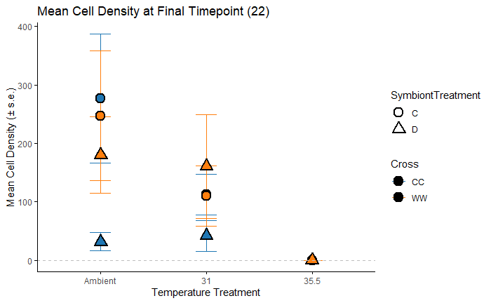

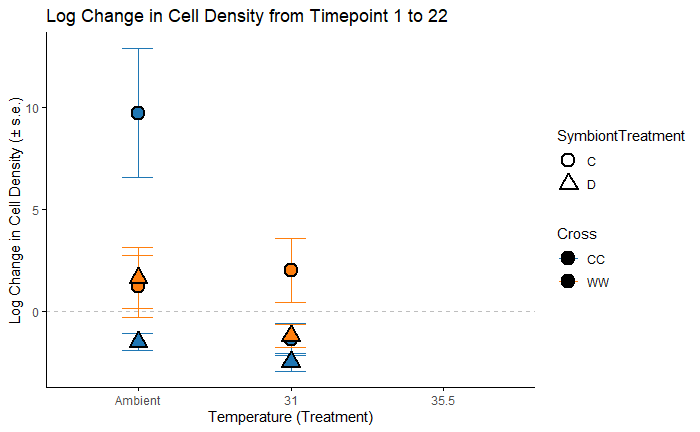

```r
print(log_change_plot_cells)
```

Cell Density by ReefMom (Log transformed)

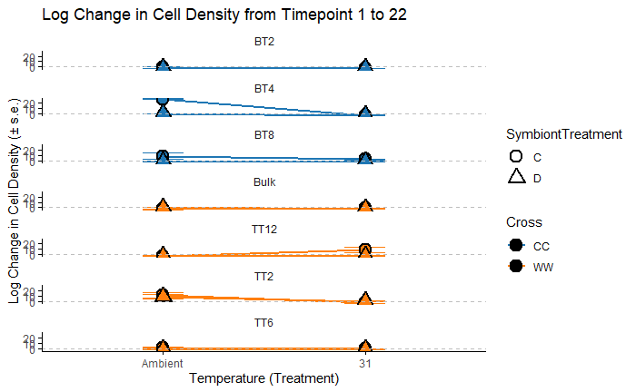

Combine all of the plots

```r
ggsave("C:/Users/jc980786/OneDrive - James Cook University/Australia/Ningaloo Spawning 2024/combined_plot_cd_log.png",
       plot = combined_plot_cd,  # Save the most recent plot
       width = 10,          # Set the width of the plot (in inches)
       height = 7,          # Set the height of the plot (in inches)
       dpi = 300)           # Set the resolution (300 dpi is good for publications)
```

##Percentage of Larvae that Acquired Cells with Source Reef

```r
summary(ipam[, c("PercChangeCells", "SymbiontTreatment", "Cross", "Treatment")])
```

```
 PercChangeCells    SymbiontTreatment Cross      Treatment
 Min.   :-100.000   C:797             CC:666   Ambient:631
 1st Qu.: -20.000   D:785             WW:916   31     :625
 Median :   0.000                              35.5   :326
 Mean   :  -2.457
 3rd Qu.:  13.333
 Max.   :  60.000
```

##ONLY SURVIVORS: Percentage of Larvae that Acquired Cells with Source Cross

|  | group1 | group2 | mean_diff | lower | upper | pMCMC | significant |
| --- | --- | --- | --- | --- | --- | --- | --- |
| 2.5% | C_CC_Ambient | D_CC_Ambient | 18.4946383 | 13.5492443 | 23.3807531 | 0.000 | TRUE |
| 2.5%1 | C_CC_Ambient | C_WW_Ambient | -2.3907089 | -6.8452801 | 2.2081957 | 0.277 | FALSE |
| 2.5%2 | C_CC_Ambient | D_WW_Ambient | -7.0210783 | -11.4293316 | -2.4820680 | 0.005 | TRUE |
| 2.5%3 | C_CC_Ambient | C_CC_31 | 7.4899600 | 1.0588946 | 13.9375314 | 0.021 | TRUE |
| 2.5%4 | C_CC_Ambient | D_CC_31 | 2.2198166 | -3.3575564 | 7.8971801 | 0.439 | FALSE |
| 2.5%5 | C_CC_Ambient | C_WW_31 | -17.2456517 | -22.9524476 | -11.4367705 | 0.000 | TRUE |
| 2.5%6 | C_CC_Ambient | D_WW_31 | -17.8204454 | -23.5367326 | -11.9177021 | 0.000 | TRUE |
| 2.5%7 | D_CC_Ambient | C_WW_Ambient | -20.8853472 | -25.0805669 | -16.3333576 | 0.000 | TRUE |
| 2.5%8 | D_CC_Ambient | D_WW_Ambient | -25.5157165 | -29.9247143 | -21.1062816 | 0.000 | TRUE |
| 2.5%9 | D_CC_Ambient | C_CC_31 | -11.0046783 | -17.0907504 | -4.8910160 | 0.002 | TRUE |

[output cut: 18 more lines]